# Poisson-Gamma Review

578

2024sep17

### Poisson distribution

if $Y \sim \text{Poisson}(\theta)$ then

- $p(Y = y \mid \theta) = \theta^y e^{-\theta} / y!$
- $\mathbb{E}(Y) = \text{Var}(Y) = \theta$

### Posterior inference

Recall how we concluded that $Y = \sum Y_i$ is a sufficient statistic for $n$ independent Bernoulli trials.

For binary data $Y_1, \dots, Y_n$,

$$\begin{align}
p(\theta \mid y) &= \frac{p(y \mid \theta) p(\theta)}{p(y)} \\
&= \frac{\theta^{\sum y_i} (1 - \theta)^{n - \sum y_i}
p(\theta)}{p(y)} & \text{(distrib of i.i.d. sample)} \\
\end{align}$$

(In the text, Hoff shows (pg 35) the ratio)
$$\begin{align}
\frac{p(\theta_a|y_1, \dots, y_n)}{p(\theta_a|y_1, \dots, y_n)}
\end{align}$$

to make the point that $\sum_{i = 1}^n Y_i$ is the only statistic that is needed to calculate posterior probabilities of $\theta$. So, the the sum of the sample (and thus the sample mean) is a *sufficient statistic* for making inference about $\theta$.

#### **Similarly,** for the Poisson,

$\sum_i y_i$ is a sufficient statistic for a sample of $n$ i.i.d. Poisson variables.

State the likelihood,

$$\begin{align}
P(Y_1 = y_1, \dots, Y_n = y_n \mid \theta) &=
\prod_i p(y_i \mid \theta) \\
&= \prod_i \frac{\theta^{y_i} e^{-\theta}}{y_i !} \\
&= \theta^{\sum_i y_i} e^{-n \theta} \prod_i \frac{1}{y_i !} &
\\
\end{align}$$

and form the ratio for two values of $\theta$,

$$\begin{align}
\frac{p(\theta_a \mid y_1, \dots, y_n)}{p(\theta_b \mid y_1, \dots,
y_n)} &= \dots
\end{align}$$

the $\prod_i 1 / y_i !$ term cancels out and the $\theta_{a, b}^{\sum_i y_i}$ terms are the only terms remaining in the fraction. As in the binomial, $\sum_i y_i$ is a sufficient statistic.

#### **Now proceed as before with binomial data**

Use Bayes to show that with Poisson data and a Gamma prior, the posterior is distrabuted as a Gamma distribution.

This is a demonstration of conjugacy.

### Conjugate prior

Using Bayes’ rule and the sampling model above

$$\begin{align}
p(\theta \mid y) &= \frac{p(\theta)p(y \mid \theta)}{p(y)} \\
&\propto p(\theta) p(y \mid \theta) \\
&\propto p(\theta) \times \theta^{\sum y_i} e^{-n\theta} \\
\end{align}$$

#### ** Now for the prior ,,,**

$$\begin{align}
\text{If }
\theta \sim \text{Gamma}(a, b)
\end{align}$$
$$\begin{align}
\text{ then }
p(\theta) = \frac{b^a}{\Gamma(a)}\theta^{a - 1} e^{-b \theta}
\end{align}$$

**Note that**
$$\begin{align}
\mathbb{E}(\theta) &= a/b
\end{align}$$
$$\begin{align}
\text{Var}(\theta) &= a/b^2
\end{align}$$

**Now show conjugacy**

$$\begin{align}
p(\theta \mid y) &= \frac{p(\theta) p(y \mid \theta)}{p(y)} \\
&= \underbrace{\left( \frac{b^a}{\Gamma(a)} \theta^{a - 1} e^{-b
\theta}
\right)}_{p(\theta)} \underbrace{\left( \theta^{\sum y_i} e^{-n \theta}
\prod_i
\frac{1}{y_i !} \right)}_{p(y \mid \theta)} \left( \frac{1}{p(y)}
\right) \\
&= c \times \left( \theta^{a - 1 + \sum y_i} e^{-(b + n) \theta}
\right)
\end{align}$$

Where $c = f(y, a, b)$  
in other words throw all the stuff that doesn’t depend on $\theta$ into the normalizing constant so that

$\int p(\theta \mid y) \; d\theta = 1$.

Like the Binomial model, we recognize from the proportionality to $\theta^{a - 1} e^{-b \theta}$ that the posterior distribution of $\theta$ is Gamma distributed. Specifically

$$\begin{align}
\theta \mid y_1, \dots, y_n \sim \text{Gamma}(a + \sum_i y_i, b + n)
\end{align}$$

and the expectation is

$$\begin{align}
\mathbb{E}(\theta \mid y_1, \dots, y_n) &= \frac{a + \sum y_i}{b +
n} \\
&= \frac{b}{b + n} \frac{a}{b} + \frac{n}{b + n}\frac{\sum y_i}{n}
\\
\end{align}$$

### Posterior predictive distribution

$$\begin{align}
p(\tilde{y} \mid y_1, \dots, y_n) &= \int_0^{\infty} p(\tilde{y}
\mid \theta, y_1, \dots, y_n) p(\theta \mid y_1, \dots, y_n) \; d\theta
& \text{Marginalization} \\
&= \int_0^{\infty} p(\tilde{y} \mid \theta) p(\theta \mid y_1,
\dots, y_n) \; d\theta & \text{Since $\tilde{y}$ and $y_i$s c.i.
given $\theta$} \\
&= \int_0^{\infty} \left[ \frac{\theta^{\tilde{y}}
e^{-\theta}}{\tilde{y}!} \right] \times \left[ \frac{(b + n)^{a + \sum
y_i}}{\Gamma(a + \sum y_i)} \theta^{a + \sum y_i - 1} e^{-(b + n)\theta}
\right] \; d\theta \\
&= \int_0^{\infty} \left[ \frac{\theta^{\tilde{y} + a + \sum y_i -
1} e^{-(b + n + 1)\theta}}{\tilde{y}!} \right] \times \left[ \frac{(b +
n)^{a + \sum y_i}}{\Gamma(a + \sum y_i)} \right] \; d\theta &
\text{Combine $\theta$s, $e$s} \\
&= \frac{(b + n)^{a + \sum y_i}}{\Gamma(\tilde{y} + 1) \Gamma(a +
\sum y_i)} \int_0^{\infty} \theta^{\tilde{y} + a + \sum y_i - 1} e^{-(b
+ n + 1)\theta} \; d\theta \\
\end{align}$$

Notice that the integrand is proportional to a Gamma density:

$$\begin{align}
& \int_0^{\infty} \frac{b^a}{\Gamma(a)} \theta^{a - 1} e^{-b \theta}
\; d\theta = 1\\
\implies& \int_0^{\infty} \theta^{a - 1} e^{-b\theta} \; d\theta =
\frac{\Gamma(a)}{b^a} \\
\end{align}$$

So

$$\begin{align}
p(\tilde{y} \mid y_1, \dots, y_n) &= \dots \\
&= \left( \frac{(b + n)^{a + \sum y_i}}{\Gamma(\tilde{y} + 1)
\Gamma(a + \sum y_i)} \right) \left( \frac{\Gamma(\tilde{y} + a + \sum
y_i)}{(b + n + 1)^{\tilde{y} + a + \sum y_i}} \right) \\
&= \left( \frac{\Gamma(\tilde{y} + a + \sum y_i)}{\Gamma(\tilde{y} +
1) \Gamma(a + \sum y_i)} \right) \left( \frac{(b + n)^{a + \sum y_i}}{(b
+ n + 1)^{\tilde{y} + a + \sum y_i}} \right) & \text{Swapping
numerators} \\
&= \left( \frac{\Gamma(\tilde{y} + a + \sum y_i)}{\Gamma(\tilde{y} +
1) \Gamma(a + \sum y_i)} \right) \left( \frac{b + n}{b + n + 1}
\right)^{a + \sum y_i} \left( \frac{1}{b + n + 1} \right)^{\tilde{y}} \\
&= \text{dnbinom}(\tilde{y}, a + \sum y_i, b + n) \\
\end{align}$$

The negative binomial distribution here, whose parameters look just like the Gamma posterior on theta, can be thought of as a predictive Poisson distribution with increased variance owing to the increased uncertainty on the value of $\theta$. Notice

$$\begin{align}
\mathbb{E}(\tilde{Y} \mid y_1, \dots, y_n) &= \frac{a + \sum y_i}{b
+ n} = \mathbb{E}(\theta \mid y_1, \dots, y_n) \\
\text{Var}(\tilde{Y} \mid y_1, \dots, y_n) &= \frac{a + \sum y_i}{b
+ n} \frac{b
+ n + 1}{b + n} = \mathbb{E}(\theta \mid y_1, \dots, y_n) \times \frac{b
+ n + 1}{b + n}
\\
\end{align}$$

So as $n$ grows large, the variance on $\tilde{Y}$ approaches the variance of its expectation $\mathbb{E}(\tilde{Y})$.

## Example: Birth Rates

In the 1990s, did women with college degrees have different numbers of children than women without college degrees?

We sample $n_1$ women without college degrees, denoted $Y_{1,1}, \dots, Y_{n_1, 1}$, and $n_2$ women with college degrees, $Y_{1, 2}, \dots, Y_{n_2, 2}$. For some parameter $\theta$ we can model the number of children for each woman as being i.i.d $\text{Poisson}(\theta_1)$ and $\text{Poisson}(\theta_2)$, respectively. We may be interested in conducting hypothesis tests to see whether or not these $\theta$ are different.

Recall that, in this two samples, the *sufficient* statistic is simply the sum of all of the $Y_i$. Say we observe

- No college: $n_1 = 111$, $\sum Y_i = 217$, $\sum Y_i / n_1 = 1.95$
- College: $n_2 = 44$, $\sum Y_i = 66$, $\sum Y_i / n_2 = 1.50$

Say our prior on both $\theta$ is $\text{Gamma(a = 2, 1)}$.

You can try different priors by changing `a` and `b` below:

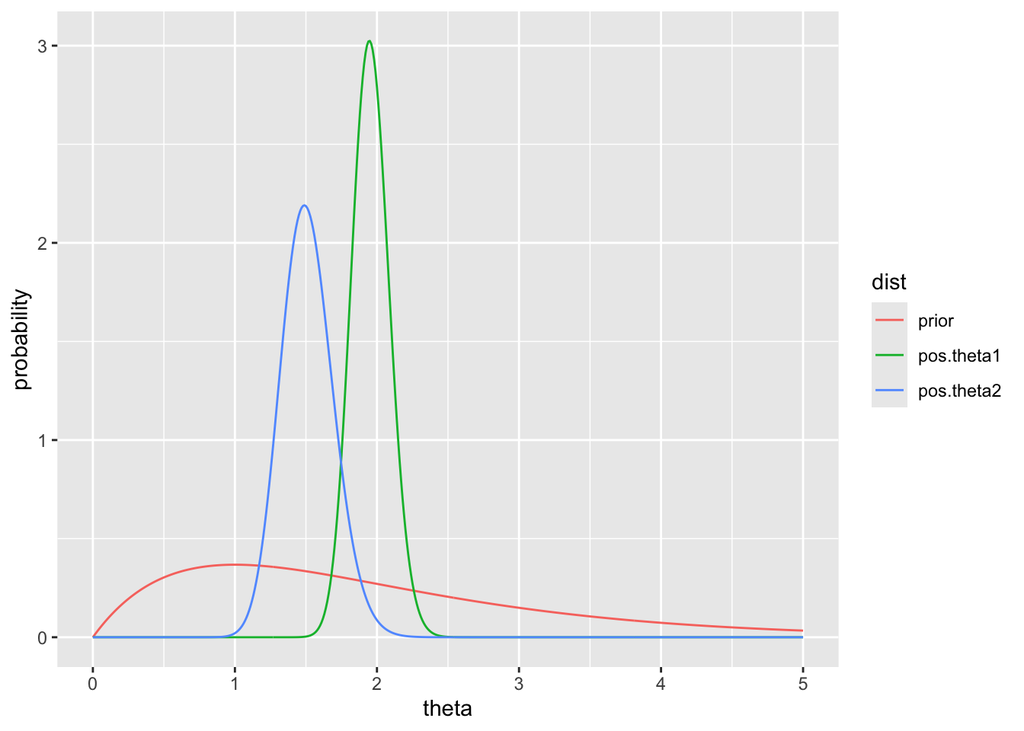

```r
a = 2
b = 1
n1 = 111
sy1 = 217
n2 = 44
sy2 = 66
df = data.frame(
  theta = seq(0, 5, by = 0.01),
  prior = dgamma(seq(0, 5, by = 0.01), a, b),
  pos.theta1 = dgamma(seq(0, 5, by = 0.01), a + sy1, b + n1),
  pos.theta2 = dgamma(seq(0, 5, by = 0.01), a + sy2, b + n2)
)
df.long = melt(df, id.vars = 'theta', variable_name = 'dist')
ggplot(df.long, aes(x = theta, y = value, group = dist, color = dist)) +
  geom_line() +
  ylab('probability')
```

Notice that we can calculate the probability that $\theta_1 > \theta_2$ by integrating over the joint density $p(\theta_1, \theta_2)$ over the region where $\theta_1 > \theta_2$.

### Calulate

OK, we have posterior distributions for women without ($\theta_1$) and with bachelor’s degrees ($\theta_2$). Recall

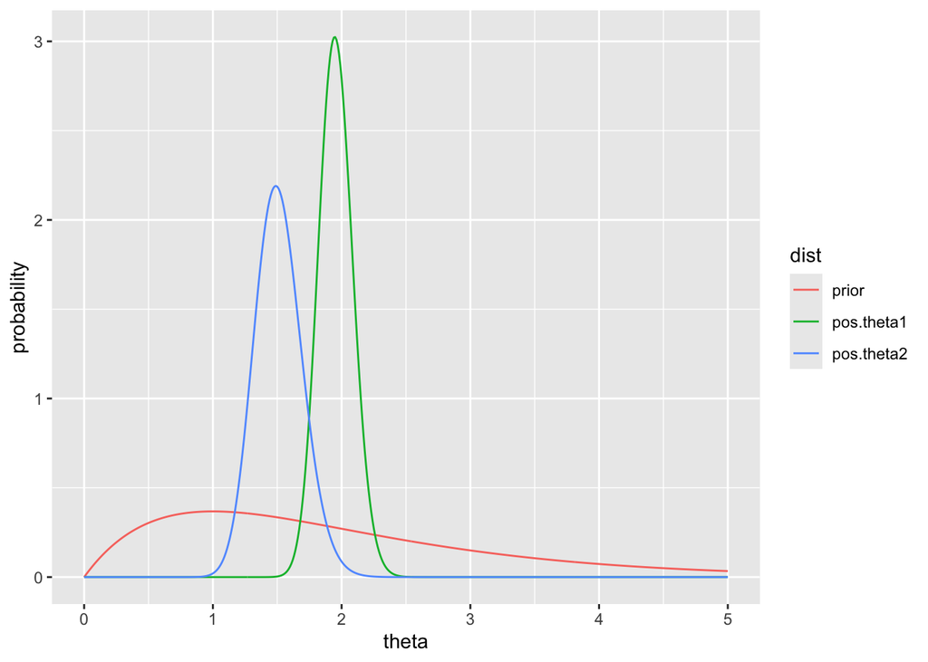

To calculate the probability under these models that the mean number of children of women without bachelor’s degrees are higher than the mean number of those with bachelor’s degrees $P(\theta_1 > \theta_2 \mid \dots)$, we can do so analytically.

Notice that since $\theta_1$ and $\theta_2$ are independent, $p(\theta_1, \theta_2) = p(\theta_1) p(\theta_2)$. If we plot $\theta_1$ and $\theta_2$ on the cartesian coordinate plane, the line $\theta_1 = \theta_2$ divides two regions of the plane - one where $\theta_1 > \theta_2$, the other where $\theta_2 > \theta_1$. We double-integrate the joint density $p(\theta_1, \theta_2)$ over the region we’re interested in.

Since for this example, the supports of $\theta_1$ and $\theta_2$ are $[0, \infty]$, we integrate over a portion of that region up to the line $\theta_1 = \theta_2$:

$$\begin{align}
P(\theta_1 > \theta_2 \mid y) &= \int_0^\infty \left(
\int_0^{\theta_1}
p(\theta_1 \mid y) p(\theta_2 \mid y) \; d\theta_2 \right) \; d\theta_1
\\
&= \int_0^\infty \left( \int_0^{\theta_1}
\text{dgamma}(\theta_1, 219, 112) \times \text{dgamma}(\theta_2, 68, 45)
\; d\theta_2 \right) \; d\theta_1 \\
\end{align}$$

Since Gamma distributions have well-defined PDFs, in this case the integral is computable and is reasonably easy in R:

```r
inner.int = function(Theta.1) {
  sapply(Theta.1, function(theta.1) {
    integrate(function(theta.2) dgamma(theta.1, 219, 112) * dgamma(theta.2, 68, 45), 0, theta.1)$value
  })
}
integrate(inner.int, 0, 50)
```

```
## 0.9725601 with absolute error < 7.9e-05
```

### Monte Carlo

When inference gets complicated, integrals may not be tractable.

calculate estimates via Monte Carlo estimation.

Notice that we can implement computational tools that allow us to sample arbitrarily from the Gamma distributions of $\theta_1$ and $\theta_2$.

The details of implementing these samplers, i.e. functions that can draw some $\theta_i \sim p(\theta \mid y)$, are non-trivial.

BUT you have R where you can make $n$ random draws from a gamma distribution with parameters $a$ and $b$ with the function call `rgamma(n, a, b)`.

The law of large numbers states that, for $S$ i.i.d. draws $\theta^1, \dots,\theta^S$ from a distribution $p(\theta)$, as $S \rightarrow \infty$, $\frac{1}{S} \sum \theta^i \rightarrow \mathbb{E}(p(\theta))$.

This also implies that the variance of the sample approaches the variance of the distribution.

By the Glivenko-Cantelli Lemma, the empirical distribution function of $\theta^1, \dots, \theta^S$ approaches $p(\theta)$.

So, you can approximate any quantity of interest of $p(\theta)$ to arbitrary precision using a large enough sample from that function.

You can see this in this example – which demonstrates how the histogram and kernel density estimates of larger and large samples from the $\theta_2 \sim \text{Gamma}(68, 45)$ distribution approach the distribution itself. In each panel, the true distribution is the dotted blue line.

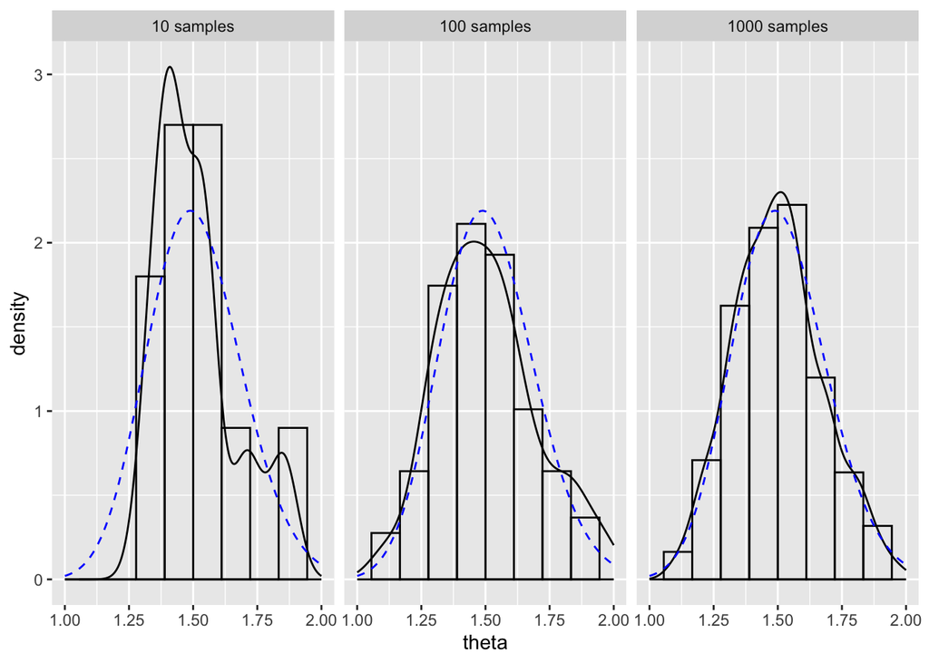

```r
a = 68
b = 45

std.gamma = data.frame(theta = seq(0, 3, by = 0.01), p = dgamma(seq(0, 3, by = 0.01), a, b))
mc10 = data.frame(theta = rgamma(10, a, b), type = '10 samples')
mc100 = data.frame(theta = rgamma(100, a, b), type = '100 samples')
mc1000 = data.frame(theta = rgamma(1000, a, b), type = '1000 samples')

mcs = rbind(mc10, mc100, mc1000)

ggplot(mcs, aes(x = theta, y = ..density..)) +
  geom_histogram(bins = 10, fill = NA, color = 'black') +
  stat_density(fill = NA, color = 'black') +
  scale_x_continuous(limits = c(1, 2)) +
  geom_line(data = std.gamma, mapping = aes(x = theta, y = p), lty = 2, color = 'blue') +
  ylab('density') +
  facet_grid(. ~ type)
```

## Numerical evaluation

The actual posterior mean of $\theta_2 \mid y$ is $68/45 = 1.51$. Notice we can approximate this mean with the mean of the above

```r
means = c('10 samples' = mean(mc10$theta),
          '100 samples' = mean(mc100$theta),
          '1000 samples' = mean(mc1000$theta))
kable(means, col.names = 'Estimate of E(theta)')
```

|  | Estimate of E(theta) |
| --- | --- |
| 10 samples | 1.513649 |
| 100 samples | 1.505915 |
| 1000 samples | 1.505229 |

We can calculate probabilities of events concerning theta by counting the number of times in our sample the randomly sampled value satisfies the event. For example, to calculate $P(\theta < 1.75 \mid y)$, we observe the number of times a sampled $\theta^{i} < 1.75$. In R, comparison operators like `>` or `==` operate element-wise, so `mc1000$theta < 1.75` returns a boolean vector of `T`s and `F`s depending on whether the specific $\theta^i$ is indeed less than 1.75:

Thus, we can calculate

```r
means = c('10 samples' = mean(mc10$theta < 1.75),
          '100 samples' = mean(mc100$theta < 1.75),
          '1000 samples' = mean(mc1000$theta < 1.75))
kable(means, col.names = 'Estimate of P(theta < 1.75)')
```

|  | Estimate of P(theta < 1.75) |
| --- | --- |
| 10 samples | 0.900 |
| 100 samples | 0.870 |
| 1000 samples | 0.901 |

Notice the true probability can be calculated with via `pgamma(1.75, 68, 45)` and is 0.9.

## Convergence

We can measure how quickly our estimates converge to the true mean (for this example, when the true mean is known) by plotting the estimate thus far as the number of samples in our estimation increase, as below:

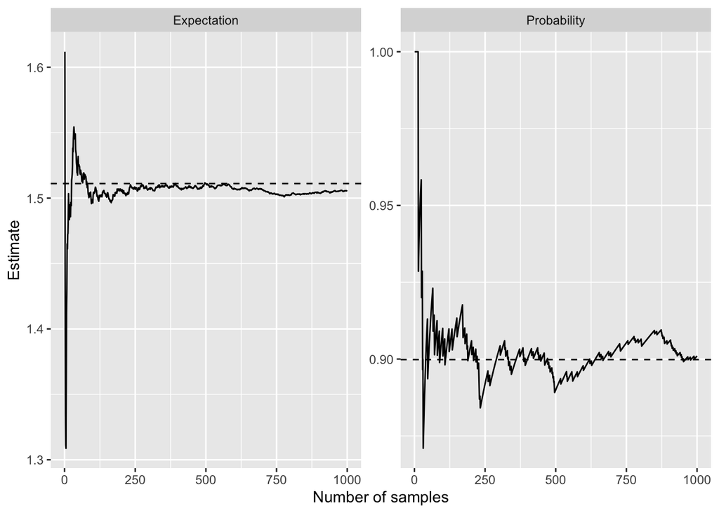

```r
cstats = melt(data.frame(
  n = seq_along(mc1000$theta),
  'Expectation' = cumsum(mc1000$theta) / seq_along(mc1000$theta),
  'Probability' = cumsum(mc1000$theta < 1.75) / seq_along(mc1000$theta < 1.75)
), id.vars = 'n')
realstats = data.frame(
  stat = c(68 / 45, pgamma(1.75, 68, 45)),
  variable = c('Expectation', 'Probability')
)
ggplot(cstats, aes(x = n, y = value)) +
  facet_wrap(~ variable, scales = 'free') +
  geom_line() +
  ylab('Estimate') + xlab('Number of samples') +
  geom_hline(data = realstats, mapping = aes(yintercept = stat), lty = 2)
```

Since, due to the central limit theorem, estimates of the mean of $\theta^1, \dots, \theta^S$ (and other quantities??) are approximately normally distributed for large $S$, we can construct confidence intervals for our estimates based on the sample size.

Specifically, an approximate 95% confidence interval for $\theta$ is

$$\hat{\theta} \pm 1.96 \sqrt{\hat{\sigma}^2 / S}$$

where $\hat{\sigma}^2$ is the unbiased estimator of the population variance (hence the *approximate* confidence interval; divide by $S - 1$, not $S$). Using this, we can estimate the number of samples we ought to take to report our estimate to a certain degree of precision. We ought to take enough samples such that the standard error $\sqrt{\hat{\sigma}^2/S} < \alpha$ where $\alpha$ is the desired level of precision. Of course, since we don’t know how variable our samples are, we don’t know how big $\hat{\sigma}^2$ is, so we cannot *a priori* determine the number of samples to run. It is possible, however, to run a smaller number of samples first to determine an estimate of $\hat{\sigma}^2$ and thus the standard error, then conservatively use that estimate to identify the size of $S$ required for the desired precision.

# Posterior inference for arbitrary functions

If we can sample $\theta^{(1)}, \dots, \theta^{(S)} \sim p(\theta \mid y)$ i.i.d., then we can obtain distributions for any arbitrary function $g(\theta)$. We just need to sample $S$ $\theta^{(i)}$, then apply $g$ to each $\theta^{(i)}$ to obtain the value of interest, say $\gamma^{(i)}$. This step is deterministic, so we are actually sampling from $p(\gamma \mid y)$. Thus, by the sample law of large numbers and central limit theorem derivations as before, Monte Carlo estimations can estimate arbitrary functions to any degree of accuracy. This is very powerful and flexible!